# Chapter 5

Today is

```r
date()
```

```
## [1] "Thu Nov 26 13:45:48 2020"
```

## 1. Descriptive Statistics

Let us get the data and summarize it

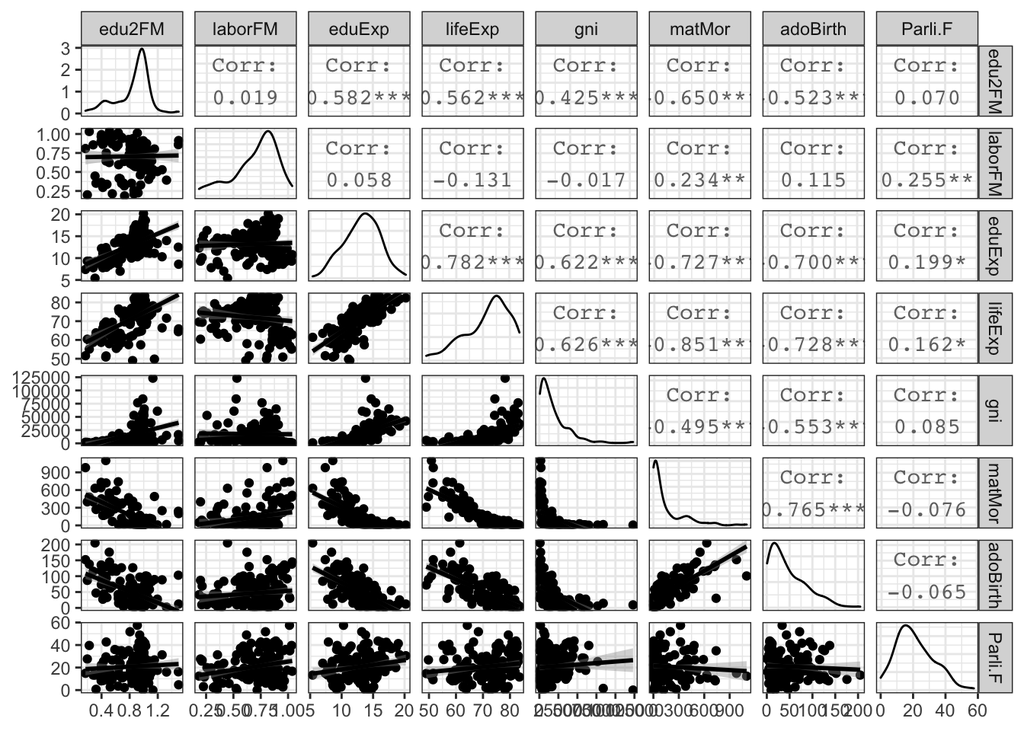

```r
library(tidyr); library(dplyr); library(ggplot2); library(GGally)

human <- read.csv("/Users/marttikaila/IODS-project/data/human.csv",row.names = 1)

ggpairs(human, lower=list(continuous="smooth")) + theme_bw()
```

```r
summary(human)
```

```
##      edu2FM          laborFM           eduExp         lifeExp
##  Min.   :0.1717   Min.   :0.1857   Min.   : 5.40   Min.   :49.00
##  1st Qu.:0.7427   1st Qu.:0.5981   1st Qu.:11.30   1st Qu.:66.42
##  Median :0.9402   Median :0.7529   Median :13.50   Median :74.20
##  Mean   :0.8559   Mean   :0.7065   Mean   :13.21   Mean   :71.79
##  3rd Qu.:0.9968   3rd Qu.:0.8531   3rd Qu.:15.20   3rd Qu.:77.28
##  Max.   :1.4967   Max.   :1.0380   Max.   :20.20   Max.   :83.50
##       gni             matMor           adoBirth         Parli.F
##  Min.   :   680   Min.   :   1.00   Min.   :  0.60   Min.   : 0.00
##  1st Qu.:  4495   1st Qu.:  11.25   1st Qu.: 12.62   1st Qu.:12.40
##  Median : 12081   Median :  49.00   Median : 33.20   Median :19.35
##  Mean   : 17739   Mean   : 144.34   Mean   : 46.83   Mean   :20.97
##  3rd Qu.: 24518   3rd Qu.: 190.00   3rd Qu.: 71.78   3rd Qu.:28.07
##  Max.   :123124   Max.   :1100.00   Max.   :204.80   Max.   :57.50
```

Otherwise, it seems that most of the variables in the data are quite skewed either to left or right. For example, most of the countries have low maternal mortality ratio and high life expectancy.

## 2. Perform principal component analysis

```r
pcaHuman <- prcomp(human)
pcaHuman$rotation
```

```
##                    PC1           PC2           PC3           PC4           PC5
## edu2FM   -5.483968e-06  0.0006774431 -6.601912e-05  2.878945e-04 -0.0023323227
## laborFM   1.870129e-07 -0.0002867019  5.722883e-04  4.679274e-03  0.0022514818
## eduExp   -9.421291e-05  0.0076121366  1.440694e-02  3.306304e-02  0.1433996994
## lifeExp  -2.763184e-04  0.0285497450  1.213702e-02  6.796002e-02  0.9864967604
## gni      -9.999844e-01 -0.0055692730 -4.949159e-04 -4.959612e-05 -0.0001134101
## matMor    5.448964e-03 -0.9907699345  1.326328e-01  4.982287e-03  0.0269365745
## adoBirth  1.224150e-03 -0.1321514487 -9.909789e-01 -1.773615e-03  0.0180452112
## Parli.F  -5.283062e-05  0.0025181281 -3.733053e-03  9.971150e-01 -0.0721036585
##                    PC6           PC7           PC8
## edu2FM    2.186025e-02 -6.993013e-01  7.144885e-01
## laborFM   3.261226e-02 -7.137754e-01 -6.995954e-01
## eduExp    9.882067e-01  3.829059e-02  7.690734e-03
## lifeExp  -1.456314e-01 -5.394540e-03  2.342731e-03
## gni      -2.712609e-05  8.052589e-07 -1.172613e-06
## matMor    1.622029e-03 -1.389882e-04  8.519581e-04
## adoBirth  1.290409e-02  9.639935e-05 -2.070969e-04
## Parli.F  -2.298641e-02  2.650395e-03  2.657465e-03
```

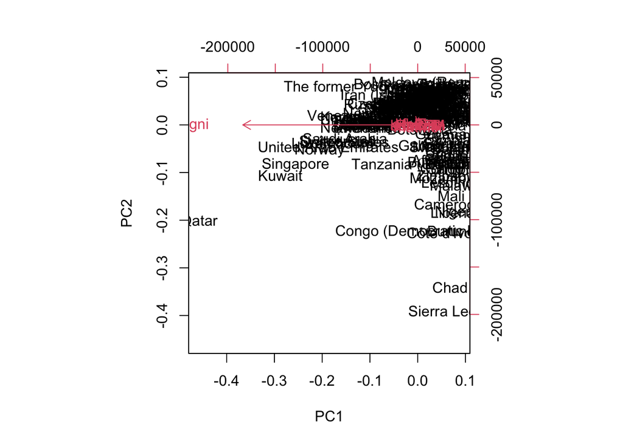

```r
biplot(pcaHuman, choices = 1:2)
```

## 3. Standardize the variables and perform the PCA again

```r
humanStand <- scale(human)
pcaHumanStand <- prcomp(humanStand)
pcaHumanStand$rotation
```

```
##                  PC1         PC2          PC3         PC4        PC5
## edu2FM   -0.35382344  0.03980714 -0.270488162  0.63097853 -0.5902171
## laborFM   0.04969988  0.72292172 -0.583380258  0.03256587  0.2732690
## eduExp   -0.42733965  0.14274470 -0.070250838 -0.08227983  0.1647802
## lifeExp  -0.44378639 -0.02498079  0.115924967 -0.06497787  0.1638079
## gni      -0.35206037  0.05093793 -0.173905607 -0.72322408 -0.5064649
## matMor    0.43773666  0.14934103 -0.116823236 -0.25031073 -0.1899463
## adoBirth  0.41337579  0.07847120  0.005439234  0.04008087 -0.4527381
## Parli.F  -0.07958597  0.65095648  0.724023091  0.04998459 -0.1594496
##                  PC6          PC7         PC8
## edu2FM    0.15144706  0.056039665  0.16581233
## laborFM  -0.01980682 -0.229987723 -0.07455496
## eduExp   -0.39949812  0.771557403 -0.05698719
## lifeExp  -0.42341909 -0.446273803  0.61602906
## gni       0.12877470 -0.135076454 -0.16978604
## matMor    0.15245990  0.350639687  0.72629812
## adoBirth -0.76211887 -0.090909783 -0.16512141
## Parli.F   0.13090790  0.006755846 -0.02464049
```

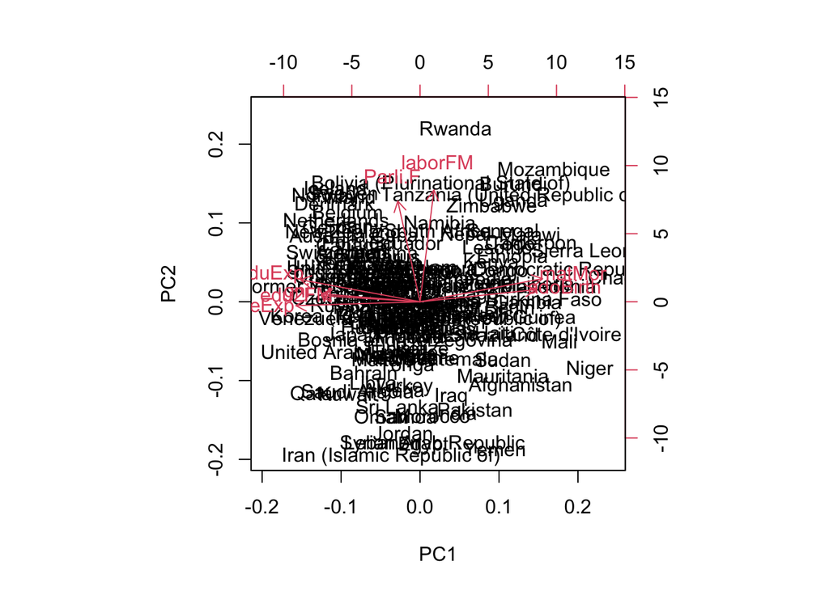

```r
biplot(pcaHumanStand, choices = 1:2)
```

Clearly the are very different. This arises from the fact that GNI has a very high variance, and hence almost all weight in the first principal component (PCA1) is going on the GNI. However, after we scale all the variable, much more reasonable picture emerges. Now multiple variables contribute to the first principal component and a couple of variables to the second component.

## 4). Interpretations of the first two principal components

### 4.1). The first principal component

Based on the figures and tables, first principal component is negatively correlated with gni, life expectancy at birth, expected years of schooling and proportion of females with at least secondary education. It positively associated with maternal mortality ratio adolescent birth rate. This component can be seen as as measures of country’s underdevelopness , which is negatively correlated with things that we can classify as “good” and positively correlated things we can regard as bad.

### 4.1). The second principal component

Second principal component is mainly and very heavily positively correlated with the percentage of female representatives in parliament and the ratio of female and labor labor force partishipaiton rates. This component - which is orthogonal to the first element, can be seen as a measurment of gender equality.